# Optimal Treatment Analysis

## Outcome Variable

**Outcome Variable:** haz

## Predictor Variables

**Intervention Variable:** hdlvry

**Adjustment Set:**

- arm
- sex
- W_mage
- meducyrs
- feducyrs
- hhwealth_quart
- single
- W_nrooms
- brthmon
- W_parity
- impsan
- delta_W_mage
- delta_meducyrs
- delta_feducyrs
- delta_hhwealth_quart
- delta_single
- delta_W_nrooms
- delta_brthmon
- delta_W_parity
- delta_impsan

## Stratifying Variables

The analysis was stratified on these variable(s):

- agecat
- studyid
- country

## Data Summary

| agecat | studyid | country | hdlvry | n_cell | n |
| --- | --- | --- | --- | --- | --- |
| Birth | ki1000108-CMC-V-BCS-2002 | INDIA | 0 | 92 | 92 |
| Birth | ki1000108-CMC-V-BCS-2002 | INDIA | 1 | 0 | 92 |
| Birth | ki1000108-IRC | INDIA | 0 | 381 | 388 |
| Birth | ki1000108-IRC | INDIA | 1 | 7 | 388 |
| Birth | ki1000109-EE | PAKISTAN | 0 | 161 | 238 |
| Birth | ki1000109-EE | PAKISTAN | 1 | 77 | 238 |
| Birth | ki1000304b-SAS-CompFeed | INDIA | 0 | 124 | 1085 |
| Birth | ki1000304b-SAS-CompFeed | INDIA | 1 | 961 | 1085 |
| Birth | ki1017093b-PROVIDE | BANGLADESH | 0 | 391 | 539 |
| Birth | ki1017093b-PROVIDE | BANGLADESH | 1 | 148 | 539 |
| Birth | ki1017093c-NIH-Crypto | BANGLADESH | 0 | 567 | 732 |
| Birth | ki1017093c-NIH-Crypto | BANGLADESH | 1 | 165 | 732 |
| Birth | ki1113344-GMS-Nepal | NEPAL | 0 | 157 | 646 |
| Birth | ki1113344-GMS-Nepal | NEPAL | 1 | 489 | 646 |
| Birth | ki1135781-COHORTS | INDIA | 0 | 2938 | 4694 |
| Birth | ki1135781-COHORTS | INDIA | 1 | 1756 | 4694 |
| Birth | kiGH5241-JiVitA-3 | BANGLADESH | 0 | 41 | 349 |
| Birth | kiGH5241-JiVitA-3 | BANGLADESH | 1 | 308 | 349 |
| Birth | kiGH5241-JiVitA-4 | BANGLADESH | 0 | 554 | 2808 |
| Birth | kiGH5241-JiVitA-4 | BANGLADESH | 1 | 2254 | 2808 |
| 6 months | ki1000108-CMC-V-BCS-2002 | INDIA | 0 | 358 | 366 |
| 6 months | ki1000108-CMC-V-BCS-2002 | INDIA | 1 | 8 | 366 |
| 6 months | ki1000108-IRC | INDIA | 0 | 399 | 407 |
| 6 months | ki1000108-IRC | INDIA | 1 | 8 | 407 |
| 6 months | ki1000109-EE | PAKISTAN | 0 | 250 | 371 |
| 6 months | ki1000109-EE | PAKISTAN | 1 | 121 | 371 |
| 6 months | ki1000304b-SAS-CompFeed | INDIA | 0 | 147 | 1091 |
| 6 months | ki1000304b-SAS-CompFeed | INDIA | 1 | 944 | 1091 |
| 6 months | ki1000304b-SAS-FoodSuppl | INDIA | 0 | 76 | 380 |
| 6 months | ki1000304b-SAS-FoodSuppl | INDIA | 1 | 304 | 380 |
| 6 months | ki1017093b-PROVIDE | BANGLADESH | 0 | 450 | 604 |
| 6 months | ki1017093b-PROVIDE | BANGLADESH | 1 | 154 | 604 |
| 6 months | ki1017093c-NIH-Crypto | BANGLADESH | 0 | 554 | 715 |
| 6 months | ki1017093c-NIH-Crypto | BANGLADESH | 1 | 161 | 715 |
| 6 months | ki1066203-TanzaniaChild2 | TANZANIA, UNITED REPUBLIC OF | 0 | 1889 | 1921 |
| 6 months | ki1066203-TanzaniaChild2 | TANZANIA, UNITED REPUBLIC OF | 1 | 32 | 1921 |
| 6 months | ki1113344-GMS-Nepal | NEPAL | 0 | 129 | 528 |
| 6 months | ki1113344-GMS-Nepal | NEPAL | 1 | 399 | 528 |
| 6 months | ki1135781-COHORTS | INDIA | 0 | 2900 | 4699 |
| 6 months | ki1135781-COHORTS | INDIA | 1 | 1799 | 4699 |
| 6 months | kiGH5241-JiVitA-3 | BANGLADESH | 0 | 39 | 332 |
| 6 months | kiGH5241-JiVitA-3 | BANGLADESH | 1 | 293 | 332 |
| 6 months | kiGH5241-JiVitA-4 | BANGLADESH | 0 | 1081 | 4038 |
| 6 months | kiGH5241-JiVitA-4 | BANGLADESH | 1 | 2957 | 4038 |
| 24 months | ki1000108-CMC-V-BCS-2002 | INDIA | 0 | 360 | 368 |
| 24 months | ki1000108-CMC-V-BCS-2002 | INDIA | 1 | 8 | 368 |
| 24 months | ki1000108-IRC | INDIA | 0 | 401 | 409 |
| 24 months | ki1000108-IRC | INDIA | 1 | 8 | 409 |
| 24 months | ki1000109-EE | PAKISTAN | 0 | 112 | 166 |
| 24 months | ki1000109-EE | PAKISTAN | 1 | 54 | 166 |
| 24 months | ki1017093b-PROVIDE | BANGLADESH | 0 | 433 | 578 |
| 24 months | ki1017093b-PROVIDE | BANGLADESH | 1 | 145 | 578 |
| 24 months | ki1017093c-NIH-Crypto | BANGLADESH | 0 | 391 | 514 |
| 24 months | ki1017093c-NIH-Crypto | BANGLADESH | 1 | 123 | 514 |
| 24 months | ki1066203-TanzaniaChild2 | TANZANIA, UNITED REPUBLIC OF | 0 | 6 | 6 |
| 24 months | ki1066203-TanzaniaChild2 | TANZANIA, UNITED REPUBLIC OF | 1 | 0 | 6 |
| 24 months | ki1113344-GMS-Nepal | NEPAL | 0 | 118 | 456 |
| 24 months | ki1113344-GMS-Nepal | NEPAL | 1 | 338 | 456 |
| 24 months | ki1135781-COHORTS | INDIA | 0 | 2233 | 3556 |
| 24 months | ki1135781-COHORTS | INDIA | 1 | 1323 | 3556 |
| 24 months | kiGH5241-JiVitA-3 | BANGLADESH | 0 | 35 | 291 |
| 24 months | kiGH5241-JiVitA-3 | BANGLADESH | 1 | 256 | 291 |
| 24 months | kiGH5241-JiVitA-4 | BANGLADESH | 0 | 1033 | 4005 |
| 24 months | kiGH5241-JiVitA-4 | BANGLADESH | 1 | 2972 | 4005 |

The following strata were considered:

- agecat: 24 months, studyid: ki1000108-CMC-V-BCS-2002, country: INDIA
- agecat: 24 months, studyid: ki1000108-IRC, country: INDIA
- agecat: 24 months, studyid: ki1000109-EE, country: PAKISTAN
- agecat: 24 months, studyid: ki1017093b-PROVIDE, country: BANGLADESH
- agecat: 24 months, studyid: ki1017093c-NIH-Crypto, country: BANGLADESH
- agecat: 24 months, studyid: ki1066203-TanzaniaChild2, country: TANZANIA, UNITED REPUBLIC OF
- agecat: 24 months, studyid: ki1113344-GMS-Nepal, country: NEPAL
- agecat: 24 months, studyid: ki1135781-COHORTS, country: INDIA
- agecat: 24 months, studyid: kiGH5241-JiVitA-3, country: BANGLADESH
- agecat: 24 months, studyid: kiGH5241-JiVitA-4, country: BANGLADESH
- agecat: 6 months, studyid: ki1000108-CMC-V-BCS-2002, country: INDIA
- agecat: 6 months, studyid: ki1000108-IRC, country: INDIA
- agecat: 6 months, studyid: ki1000109-EE, country: PAKISTAN
- agecat: 6 months, studyid: ki1000304b-SAS-CompFeed, country: INDIA
- agecat: 6 months, studyid: ki1000304b-SAS-FoodSuppl, country: INDIA
- agecat: 6 months, studyid: ki1017093b-PROVIDE, country: BANGLADESH
- agecat: 6 months, studyid: ki1017093c-NIH-Crypto, country: BANGLADESH
- agecat: 6 months, studyid: ki1066203-TanzaniaChild2, country: TANZANIA, UNITED REPUBLIC OF
- agecat: 6 months, studyid: ki1113344-GMS-Nepal, country: NEPAL
- agecat: 6 months, studyid: ki1135781-COHORTS, country: INDIA
- agecat: 6 months, studyid: kiGH5241-JiVitA-3, country: BANGLADESH
- agecat: 6 months, studyid: kiGH5241-JiVitA-4, country: BANGLADESH
- agecat: Birth, studyid: ki1000108-CMC-V-BCS-2002, country: INDIA
- agecat: Birth, studyid: ki1000108-IRC, country: INDIA
- agecat: Birth, studyid: ki1000109-EE, country: PAKISTAN
- agecat: Birth, studyid: ki1000304b-SAS-CompFeed, country: INDIA
- agecat: Birth, studyid: ki1017093b-PROVIDE, country: BANGLADESH
- agecat: Birth, studyid: ki1017093c-NIH-Crypto, country: BANGLADESH
- agecat: Birth, studyid: ki1113344-GMS-Nepal, country: NEPAL
- agecat: Birth, studyid: ki1135781-COHORTS, country: INDIA
- agecat: Birth, studyid: kiGH5241-JiVitA-3, country: BANGLADESH
- agecat: Birth, studyid: kiGH5241-JiVitA-4, country: BANGLADESH

### Dropped Strata

- agecat: Birth, studyid: ki1000108-CMC-V-BCS-2002, country: INDIA
- agecat: 24 months, studyid: ki1066203-TanzaniaChild2, country: TANZANIA, UNITED REPUBLIC OF

## Methods Detail

We’re interested in the causal parameters $E[Y_a]$ for all values of $a \in \mathcal{A}$. These parameters represent the mean outcome if, possibly contrary to fact, we intervened to set all units to have $A=a$. Under the randomization and positivity assumptions, these are identified by the statistical parameters $\psi_a=E_W[E_{Y|A,W}(Y|A=a,W)]$. In addition, we’re interested in the mean of $Y$, $E[Y]$ under no intervention (the observed mean). We will estimate these parameters by using SuperLearner to fit the relevant likelihood factors – $E_{Y|A,W}(Y|A=a,W)$ and $p(A=a|W)$, and then updating our likelihood fit using a joint TMLE.

For unadjusted analyses ($W=\{\}$), initial likelihoods were estimated using Lrnr_glm to estimate the simple $E(Y|A)$ and Lrnr_mean to estimate $p(A)$. For adjusted analyses, a small library containing Lrnr_glmnet, Lrnr_xgboost, and Lrnr_mean was used.

Having estimated these parameters, we will then use the delta method to estimate relative risks and attributable risks relative to a prespecified baseline level of $A$.

# Results Detail

## Results Plots

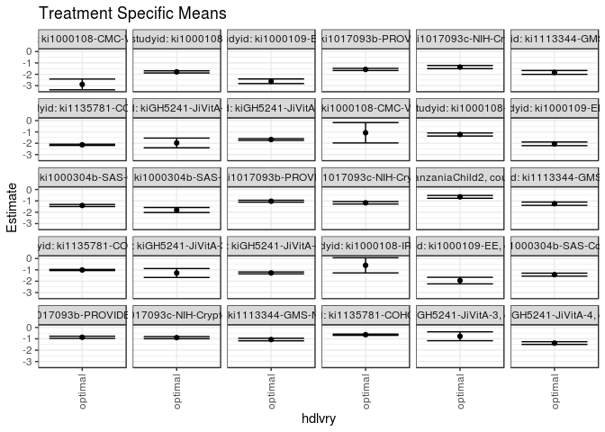

## Results Table

### Parameter: TSM

| agecat | studyid | country | intervention_level | baseline_level | estimate | ci_lower | ci_upper |
| --- | --- | --- | --- | --- | --- | --- | --- |
| Birth | ki1000108-IRC | INDIA | optimal | observed | -0.6007180 | -1.2692584 | 0.0678224 |
| Birth | ki1000109-EE | PAKISTAN | optimal | observed | -1.9449133 | -2.2360192 | -1.6538074 |
| Birth | ki1000304b-SAS-CompFeed | INDIA | optimal | observed | -1.4246252 | -1.5554399 | -1.2938105 |
| Birth | ki1017093b-PROVIDE | BANGLADESH | optimal | observed | -0.8653435 | -0.9614418 | -0.7692452 |
| Birth | ki1017093c-NIH-Crypto | BANGLADESH | optimal | observed | -0.8954562 | -0.9895897 | -0.8013226 |
| Birth | ki1113344-GMS-Nepal | NEPAL | optimal | observed | -1.0639460 | -1.1752333 | -0.9526586 |
| Birth | ki1135781-COHORTS | INDIA | optimal | observed | -0.6420491 | -0.6959896 | -0.5881086 |
| Birth | kiGH5241-JiVitA-3 | BANGLADESH | optimal | observed | -0.7756904 | -1.1675038 | -0.3838769 |
| Birth | kiGH5241-JiVitA-4 | BANGLADESH | optimal | observed | -1.3747231 | -1.4919384 | -1.2575078 |
| 6 months | ki1000108-CMC-V-BCS-2002 | INDIA | optimal | observed | -1.0752073 | -1.9722808 | -0.1781338 |
| 6 months | ki1000108-IRC | INDIA | optimal | observed | -1.2278664 | -1.3620681 | -1.0936648 |
| 6 months | ki1000109-EE | PAKISTAN | optimal | observed | -2.0500242 | -2.2099174 | -1.8901311 |
| 6 months | ki1000304b-SAS-CompFeed | INDIA | optimal | observed | -1.4046692 | -1.4962983 | -1.3130401 |
| 6 months | ki1000304b-SAS-FoodSuppl | INDIA | optimal | observed | -1.8032582 | -2.0257436 | -1.5807727 |
| 6 months | ki1017093b-PROVIDE | BANGLADESH | optimal | observed | -1.0295546 | -1.1148806 | -0.9442285 |
| 6 months | ki1017093c-NIH-Crypto | BANGLADESH | optimal | observed | -1.1701834 | -1.2772636 | -1.0631031 |
| 6 months | ki1066203-TanzaniaChild2 | TANZANIA, UNITED REPUBLIC OF | optimal | observed | -0.6448974 | -0.7667548 | -0.5230400 |
| 6 months | ki1113344-GMS-Nepal | NEPAL | optimal | observed | -1.2492512 | -1.3929524 | -1.1055499 |
| 6 months | ki1135781-COHORTS | INDIA | optimal | observed | -1.0122091 | -1.0611371 | -0.9632811 |
| 6 months | kiGH5241-JiVitA-3 | BANGLADESH | optimal | observed | -1.2777205 | -1.6700669 | -0.8853742 |
| 6 months | kiGH5241-JiVitA-4 | BANGLADESH | optimal | observed | -1.2704795 | -1.3544842 | -1.1864749 |
| 24 months | ki1000108-CMC-V-BCS-2002 | INDIA | optimal | observed | -2.8928232 | -3.3656506 | -2.4199958 |
| 24 months | ki1000108-IRC | INDIA | optimal | observed | -1.7870155 | -1.8819635 | -1.6920675 |
| 24 months | ki1000109-EE | PAKISTAN | optimal | observed | -2.6149613 | -2.8184359 | -2.4114867 |
| 24 months | ki1017093b-PROVIDE | BANGLADESH | optimal | observed | -1.5730628 | -1.6694486 | -1.4766770 |
| 24 months | ki1017093c-NIH-Crypto | BANGLADESH | optimal | observed | -1.3642898 | -1.5013547 | -1.2272249 |
| 24 months | ki1113344-GMS-Nepal | NEPAL | optimal | observed | -1.8368629 | -2.0071142 | -1.6666116 |
| 24 months | ki1135781-COHORTS | INDIA | optimal | observed | -2.1389682 | -2.1941825 | -2.0837539 |
| 24 months | kiGH5241-JiVitA-3 | BANGLADESH | optimal | observed | -1.9706785 | -2.3986149 | -1.5427421 |
| 24 months | kiGH5241-JiVitA-4 | BANGLADESH | optimal | observed | -1.6736002 | -1.7506944 | -1.5965059 |

### Parameter: E(Y)

| agecat | studyid | country | intervention_level | baseline_level | estimate | ci_lower | ci_upper |
| --- | --- | --- | --- | --- | --- | --- | --- |
| Birth | ki1000108-IRC | INDIA | observed | observed | -0.3080412 | -0.4687931 | -0.1472894 |
| Birth | ki1000109-EE | PAKISTAN | observed | observed | -1.8614286 | -2.0501173 | -1.6727398 |
| Birth | ki1000304b-SAS-CompFeed | INDIA | observed | observed | -1.4401843 | -1.5334809 | -1.3468878 |
| Birth | ki1017093b-PROVIDE | BANGLADESH | observed | observed | -0.8851020 | -0.9601332 | -0.8100709 |
| Birth | ki1017093c-NIH-Crypto | BANGLADESH | observed | observed | -0.9094945 | -0.9809370 | -0.8380521 |
| Birth | ki1113344-GMS-Nepal | NEPAL | observed | observed | -1.0909443 | -1.1734385 | -1.0084500 |
| Birth | ki1135781-COHORTS | INDIA | observed | observed | -0.6762420 | -0.7093108 | -0.6431732 |
| Birth | kiGH5241-JiVitA-3 | BANGLADESH | observed | observed | -1.2665330 | -1.4233277 | -1.1097382 |
| Birth | kiGH5241-JiVitA-4 | BANGLADESH | observed | observed | -1.5216453 | -1.5715117 | -1.4717789 |
| 6 months | ki1000108-CMC-V-BCS-2002 | INDIA | observed | observed | -1.4189572 | -1.5607165 | -1.2771979 |
| 6 months | ki1000108-IRC | INDIA | observed | observed | -1.2344062 | -1.3658524 | -1.1029600 |
| 6 months | ki1000109-EE | PAKISTAN | observed | observed | -2.0826460 | -2.2022514 | -1.9630406 |
| 6 months | ki1000304b-SAS-CompFeed | INDIA | observed | observed | -1.4699588 | -1.5446559 | -1.3952616 |
| 6 months | ki1000304b-SAS-FoodSuppl | INDIA | observed | observed | -1.8986842 | -2.0118892 | -1.7854792 |
| 6 months | ki1017093b-PROVIDE | BANGLADESH | observed | observed | -1.0916915 | -1.1661176 | -1.0172654 |
| 6 months | ki1017093c-NIH-Crypto | BANGLADESH | observed | observed | -1.1986783 | -1.2700937 | -1.1272630 |
| 6 months | ki1066203-TanzaniaChild2 | TANZANIA, UNITED REPUBLIC OF | observed | observed | -0.5440573 | -0.5945614 | -0.4935533 |
| 6 months | ki1113344-GMS-Nepal | NEPAL | observed | observed | -1.3296275 | -1.4093037 | -1.2499514 |
| 6 months | ki1135781-COHORTS | INDIA | observed | observed | -1.0458076 | -1.0793244 | -1.0122908 |
| 6 months | kiGH5241-JiVitA-3 | BANGLADESH | observed | observed | -1.3017169 | -1.4476325 | -1.1558012 |
| 6 months | kiGH5241-JiVitA-4 | BANGLADESH | observed | observed | -1.3481303 | -1.3904710 | -1.3057895 |
| 24 months | ki1000108-CMC-V-BCS-2002 | INDIA | observed | observed | -2.5611005 | -2.6603759 | -2.4618252 |
| 24 months | ki1000108-IRC | INDIA | observed | observed | -1.7987775 | -1.8923914 | -1.7051636 |
| 24 months | ki1000109-EE | PAKISTAN | observed | observed | -2.6770382 | -2.8210532 | -2.5330231 |
| 24 months | ki1017093b-PROVIDE | BANGLADESH | observed | observed | -1.6024221 | -1.6857420 | -1.5191023 |
| 24 months | ki1017093c-NIH-Crypto | BANGLADESH | observed | observed | -1.4412646 | -1.5249156 | -1.3576135 |
| 24 months | ki1113344-GMS-Nepal | NEPAL | observed | observed | -1.8717982 | -1.9591776 | -1.7844189 |
| 24 months | ki1135781-COHORTS | INDIA | observed | observed | -2.2218335 | -2.2619519 | -2.1817151 |
| 24 months | kiGH5241-JiVitA-3 | BANGLADESH | observed | observed | -2.1628866 | -2.3052995 | -2.0204737 |
| 24 months | kiGH5241-JiVitA-4 | BANGLADESH | observed | observed | -1.7725918 | -1.8111207 | -1.7340629 |

### Parameter: PAR

| agecat | studyid | country | intervention_level | baseline_level | estimate | ci_lower | ci_upper |
| --- | --- | --- | --- | --- | --- | --- | --- |
| Birth | ki1000108-IRC | INDIA | optimal | observed | 0.2926767 | -0.3751442 | 0.9604977 |
| Birth | ki1000109-EE | PAKISTAN | optimal | observed | 0.0834847 | -0.1293656 | 0.2963350 |
| Birth | ki1000304b-SAS-CompFeed | INDIA | optimal | observed | -0.0155591 | -0.0975033 | 0.0663851 |
| Birth | ki1017093b-PROVIDE | BANGLADESH | optimal | observed | -0.0197585 | -0.0752361 | 0.0357190 |
| Birth | ki1017093c-NIH-Crypto | BANGLADESH | optimal | observed | -0.0140384 | -0.0804217 | 0.0523450 |
| Birth | ki1113344-GMS-Nepal | NEPAL | optimal | observed | -0.0269983 | -0.1172040 | 0.0632074 |
| Birth | ki1135781-COHORTS | INDIA | optimal | observed | -0.0341929 | -0.0751845 | 0.0067987 |
| Birth | kiGH5241-JiVitA-3 | BANGLADESH | optimal | observed | -0.4908426 | -0.8363641 | -0.1453211 |
| Birth | kiGH5241-JiVitA-4 | BANGLADESH | optimal | observed | -0.1469222 | -0.2515664 | -0.0422780 |
| 6 months | ki1000108-CMC-V-BCS-2002 | INDIA | optimal | observed | -0.3437499 | -1.2322184 | 0.5447186 |
| 6 months | ki1000108-IRC | INDIA | optimal | observed | -0.0065398 | -0.0196539 | 0.0065743 |
| 6 months | ki1000109-EE | PAKISTAN | optimal | observed | -0.0326218 | -0.1437785 | 0.0785349 |
| 6 months | ki1000304b-SAS-CompFeed | INDIA | optimal | observed | -0.0652895 | -0.1390970 | 0.0085179 |
| 6 months | ki1000304b-SAS-FoodSuppl | INDIA | optimal | observed | -0.0954261 | -0.2930137 | 0.1021616 |
| 6 months | ki1017093b-PROVIDE | BANGLADESH | optimal | observed | -0.0621369 | -0.1064540 | -0.0178199 |
| 6 months | ki1017093c-NIH-Crypto | BANGLADESH | optimal | observed | -0.0284950 | -0.1033874 | 0.0463975 |
| 6 months | ki1066203-TanzaniaChild2 | TANZANIA, UNITED REPUBLIC OF | optimal | observed | 0.1008400 | -0.0087557 | 0.2104358 |
| 6 months | ki1113344-GMS-Nepal | NEPAL | optimal | observed | -0.0803764 | -0.2104181 | 0.0496654 |
| 6 months | ki1135781-COHORTS | INDIA | optimal | observed | -0.0335985 | -0.0685207 | 0.0013237 |
| 6 months | kiGH5241-JiVitA-3 | BANGLADESH | optimal | observed | -0.0239963 | -0.3705313 | 0.3225386 |
| 6 months | kiGH5241-JiVitA-4 | BANGLADESH | optimal | observed | -0.0776508 | -0.1477685 | -0.0075330 |
| 24 months | ki1000108-CMC-V-BCS-2002 | INDIA | optimal | observed | 0.3317227 | -0.1358553 | 0.7993007 |
| 24 months | ki1000108-IRC | INDIA | optimal | observed | -0.0117620 | -0.0259374 | 0.0024135 |
| 24 months | ki1000109-EE | PAKISTAN | optimal | observed | -0.0620768 | -0.2214057 | 0.0972520 |
| 24 months | ki1017093b-PROVIDE | BANGLADESH | optimal | observed | -0.0293594 | -0.0764634 | 0.0177447 |
| 24 months | ki1017093c-NIH-Crypto | BANGLADESH | optimal | observed | -0.0769748 | -0.1807281 | 0.0267785 |
| 24 months | ki1113344-GMS-Nepal | NEPAL | optimal | observed | -0.0349354 | -0.1804126 | 0.1105418 |
| 24 months | ki1135781-COHORTS | INDIA | optimal | observed | -0.0828653 | -0.1215894 | -0.0441413 |
| 24 months | kiGH5241-JiVitA-3 | BANGLADESH | optimal | observed | -0.1922081 | -0.5593779 | 0.1749617 |
| 24 months | kiGH5241-JiVitA-4 | BANGLADESH | optimal | observed | -0.0989916 | -0.1659825 | -0.0320007 |